# Analysis of the Wordle word list

Gary Lu

3/14/2022

### This may contain **SPOILERS** for Wordle.

#### The wordlist was extracted from the developer tools in a web browser, however it also contains *SPOILERS* for future days so I had to be careful when looking at this

#### *This information is not meant to be taken seriously as you should be playing Wordle the way you want to.*

I will take a look a common letters, as well as letter patterns

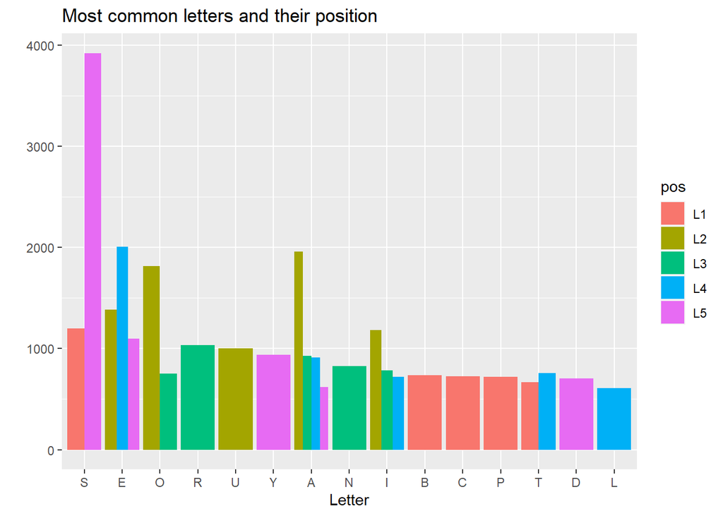

- S is the most common 5th letter probably because plural words - A E and I are popular in at least 3 different positions - I expected T and N to be more popular as anyone that has seen Wheel of Fortune knows how they are used

If were were to remove S from the 5th letter:

Side by side comparisons

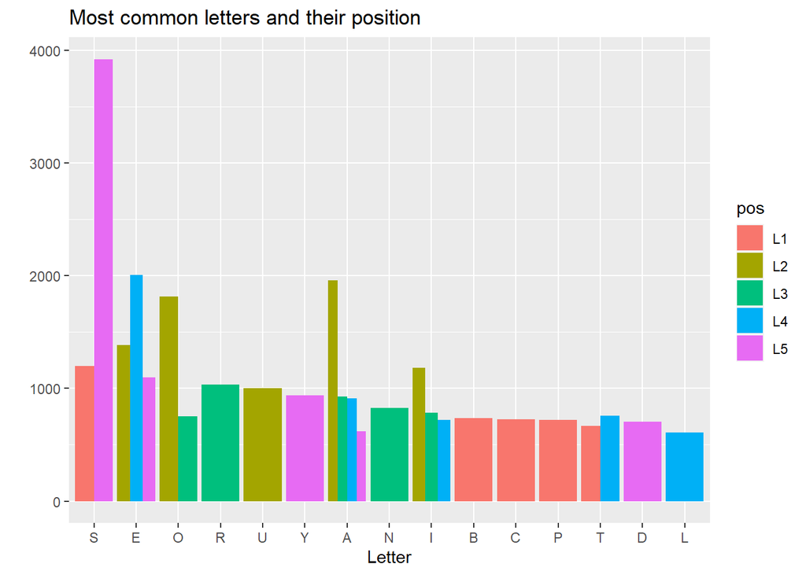

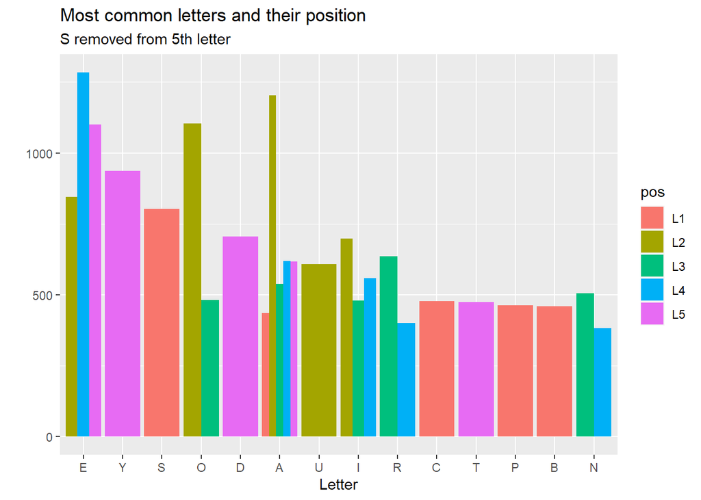

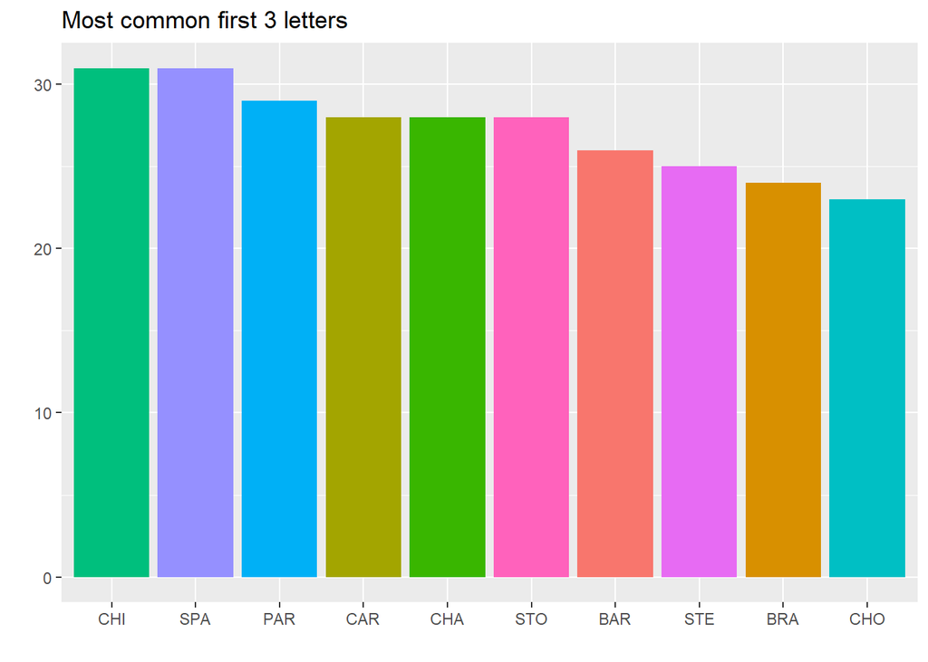

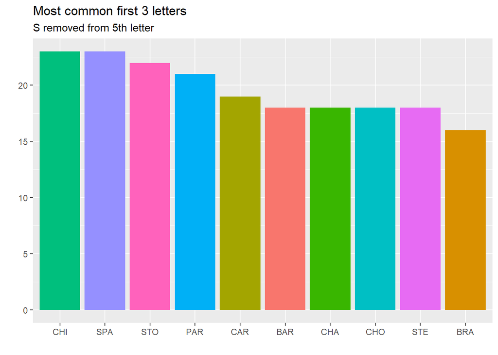

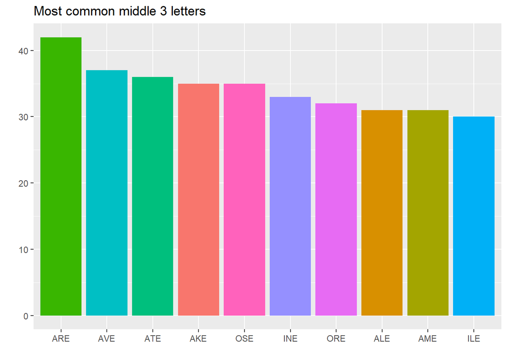

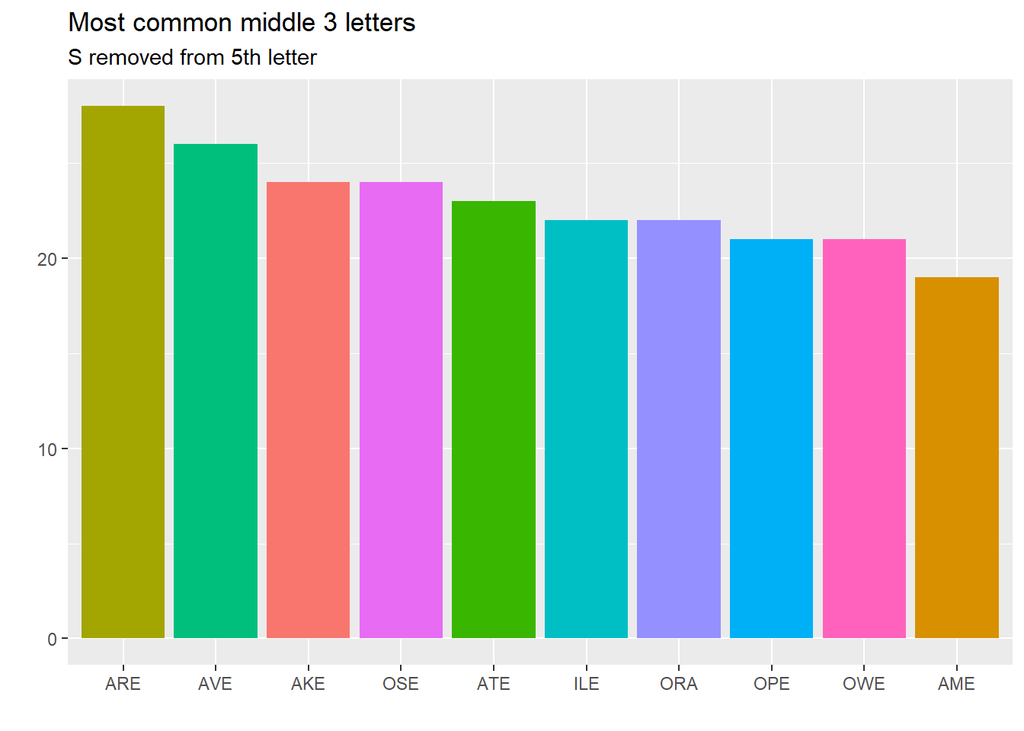

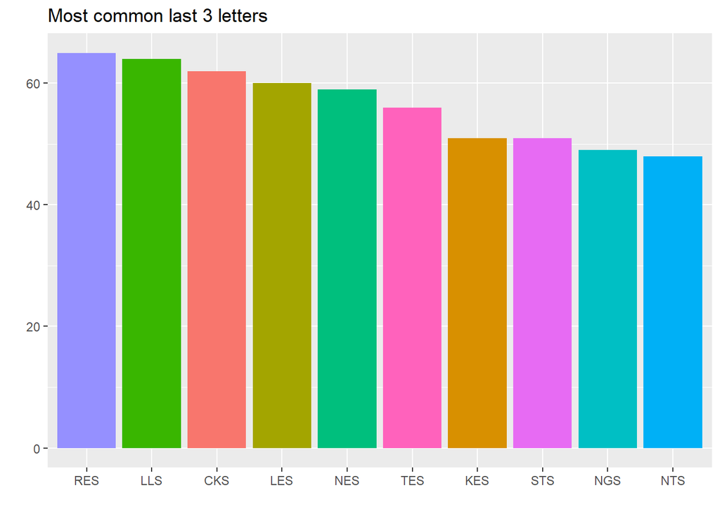

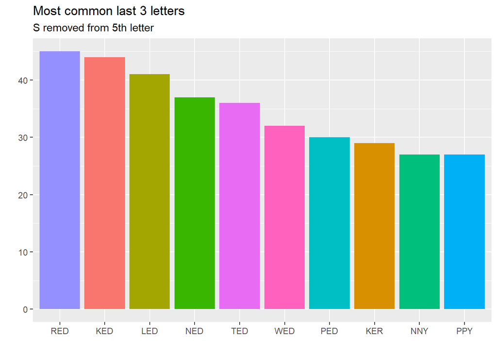

Some points of my wordle strategy:

- Start with the same word every time
- Use 5 different letters
- If any letters match, I use them in the next guess
- Do not aim to get the word on the first guess

Takeaway points so far:

- S is the most common first and last letter
- ED is the most common ending if you remove S from the 5th letter
- A can be found in the middle 3 letters all the time

If I were to follow the above, then words like SARED, SATED, SAWED, SAPED, SAKER, SANNY, SAPPY would all be potential first guesses. However, these words will only be the correct *once* over the span of many years. So if I dont have any matches in my first guess, I should have a second one ready that covers the most common letters

Let’s say we started with SATED, and ended up getting no matches

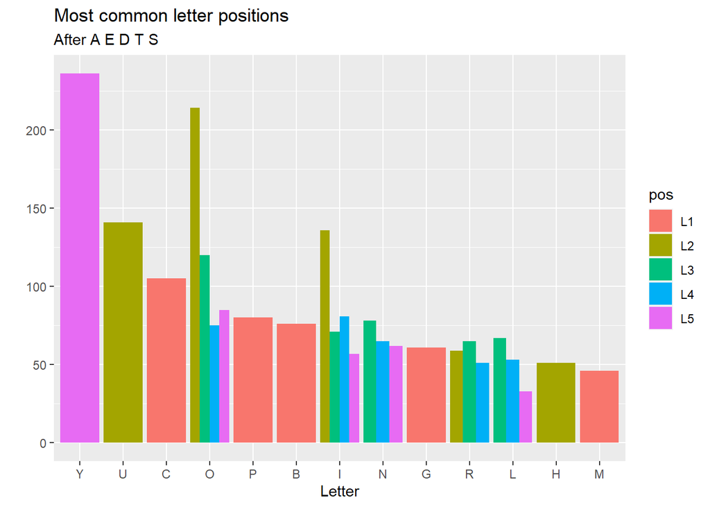

The letters O I N R L all appear multiple times, unfortunately there isn’t a word on the list that I can make with these letters

Going back, our first word was SATED which leaves our ideal opening words to contain:

- AEIO for vowels
- NRLTDS for consonants

With some guess, check and revise, there are probably many 2 word combinations from these 10 letters. Now let’s say after using those 10 letters you still didnt have any matches

```
## # A tibble: 35 x 1
##    word
##    <chr>
##  1 BUBBY
##  2 BUCHU
##  3 BUCKU
##  4 BUFFY
##  5 BUMPH
##  6 BUMPY
##  7 BUPPY
##  8 BUZZY
##  9 CHUFF
## 10 CUBBY
## # ... with 25 more rows
```

This leaves only 35 possible words. So it’s safe to say that the letters AEIONRLTDS covers a vast majority of English words so your first guess in Wordle should include these

*For the Scrabble players: These letters are all worth 1 point in Scrabble*

Concluding notes:

- This doesn’t mean that you should always start off with things like ADORE and LINTS for your first 2 guesses.
- The only thing I can guarantee is that it’s a high probability that the word has at least *one* of these 10 letters
- An example would be the word I used at the time of writing this (3/23/22) which is PURGE. Only 2 of the top 10 letters are used